# KE 5107 CA 1: EDA

**Overview** We are currently using 2018 data from Back Blaze. These are SMART stats for each hard disk drive in operation and whether it fails or not. The data is mapped across days in a year.

The Exploratory Data Analyses (EDAs) that we run on this dataset are:

1. Counts & Dimensions
- Dimension of dataset
- Count of dates, failed (1) vs OK (0) hard drives
- Proportion of failed vs OK hard drives
2. Data types
- Data Summary
- Missing data & When they are missing
- Data with no variances
3. Correlations between features

```r
##### load libraries

library (openxlsx)
library(lattice)
library (DataExplorer) # https://datascienceplus.com/blazing-fast-eda-in-r-with-dataexplorer/
library(corrplot)
library(dplyr)
#### Variables
filename <- paste("collected",".xlsx", sep = "")

#### Load dataset
hd = read.xlsx(filename, detectDates= TRUE)
```

**Dimension of Dataset**

```r
dim(hd)
```

```
## [1] 32056   106
```

**Counts**

1. Unique Dates

```r
length(unique(hd$date))
```

```
## [1] 288
```

2. failed (1) vs OK (0) hard drives

```r
count(hd, failure)
```

| failure | n |
| --- | --- |
| 0 | 31475 |
| 1 | 581 |

Distribution of failed (1) vs OK (0) hard drives across time?

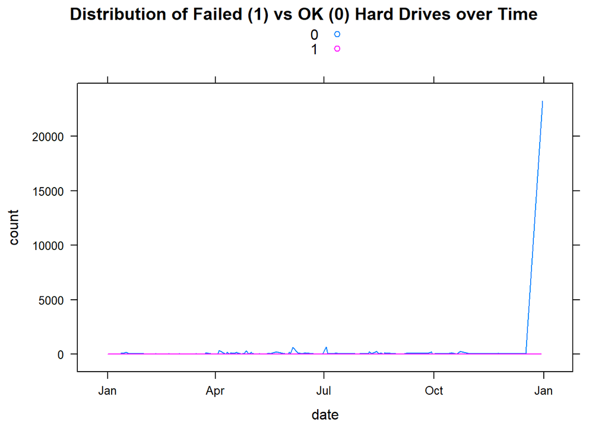

```r
temp <- hd %>%
  group_by(date, failure) %>%
  summarize(count=n())

xyplot(count~date, temp, groups=failure, type="l", auto.key=TRUE, main="Distribution of Failed (1) vs OK (0) Hard Drives over Time")
```

**Data types**

Summary of Dataset

```r
summary(hd)
```

```
##       date            serial_number         model
##  Min.   :2018-01-01   Length:32056       Length:32056
##  1st Qu.:2018-10-23   Class :character   Class :character
##  Median :2018-12-31   Mode  :character   Mode  :character
##  Mean   :2018-11-09
##  3rd Qu.:2018-12-31
##  Max.   :2018-12-31
##
##  capacity_bytes         failure        smart_1_normalized
##  Min.   :4.001e+12   Min.   :0.00000   Min.   : 83.0
##  1st Qu.:4.001e+12   1st Qu.:0.00000   1st Qu.:114.0
##  Median :4.001e+12   Median :0.00000   Median :117.0
##  Mean   :4.001e+12   Mean   :0.01812   Mean   :115.3
##  3rd Qu.:4.001e+12   3rd Qu.:0.00000   3rd Qu.:118.0
##  Max.   :4.001e+12   Max.   :1.00000   Max.   :120.0
##
##   smart_1_raw        smart_2_normalized  smart_2_raw    smart_3_normalized
##  Min.   :     1504   Min.   : NA        Min.   : NA     Min.   : 91.00
##  1st Qu.: 61199404   1st Qu.: NA        1st Qu.: NA     1st Qu.: 91.00
##  Median :121765608   Median : NA        Median : NA     Median : 92.00
##  Mean   :121967652   Mean   :NaN        Mean   :NaN     Mean   : 92.89
##  3rd Qu.:182481482   3rd Qu.: NA        3rd Qu.: NA     3rd Qu.: 94.00
##  Max.   :244135624   Max.   : NA        Max.   : NA     Max.   :100.00
##                      NA's   :32056      NA's   :32056
##   smart_3_raw smart_4_normalized  smart_4_raw      smart_5_normalized
##  Min.   :0    Min.   : 98        Min.   :   1.00   Min.   : 61.00
##  1st Qu.:0    1st Qu.:100        1st Qu.:   6.00   1st Qu.:100.00
##  Median :0    Median :100        Median :  10.00   Median :100.00
##  Mean   :0    Mean   :100        Mean   :  11.83   Mean   : 99.99
##  3rd Qu.:0    3rd Qu.:100        3rd Qu.:  15.00   3rd Qu.:100.00
##  Max.   :0    Max.   :100        Max.   :2690.00   Max.   :100.00
##
##   smart_5_raw       smart_7_normalized  smart_7_raw
##  Min.   :    0.00   Min.   :24.00      Min.   :1.374e+04
##  1st Qu.:    0.00   1st Qu.:83.00      1st Qu.:2.190e+08
##  Median :    0.00   Median :84.00      Median :3.247e+08
##  Mean   :   19.69   Mean   :84.22      Mean   :1.031e+10
##  3rd Qu.:    0.00   3rd Qu.:87.00      3rd Qu.:4.806e+08
##  Max.   :64728.00   Max.   :90.00      Max.   :2.815e+14
##
```

[output cut: 209 more lines]

```
##  Min.   : NA          Min.   : NA     Min.   : NA          Min.   : NA
##  1st Qu.: NA          1st Qu.: NA     1st Qu.: NA          1st Qu.: NA
##  Median : NA          Median : NA     Median : NA          Median : NA
##  Mean   :NaN          Mean   :NaN     Mean   :NaN          Mean   :NaN
##  3rd Qu.: NA          3rd Qu.: NA     3rd Qu.: NA          3rd Qu.: NA
##  Max.   : NA          Max.   : NA     Max.   : NA          Max.   : NA
##  NA's   :32056        NA's   :32056   NA's   :32056        NA's   :32056
##    LatestRec
##  Min.   :1
##  1st Qu.:1
##  Median :1
##  Mean   :1
##  3rd Qu.:1
##  Max.   :1
##  NA's   :581
```

Missing Columns

```r
missingHD <- colSums(is.na(hd))/nrow(hd)*100
```

Number of columns with >90% missing data: 40 (about 37.7358491%)

Which columns are Missing then?

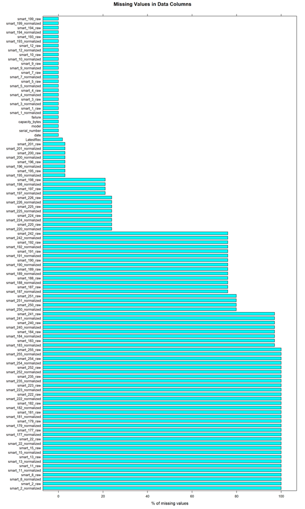

```r
barchart(sort(missingHD,decreasing = TRUE), xlab = "% of missing values", main="Missing Values in Data Columns")
```

**Remove these columns:** smart_2_normalized, smart_2_raw, smart_8_normalized, smart_8_raw, smart_11_normalized, smart_11_raw, smart_13_normalized, smart_13_raw, smart_15_normalized, smart_15_raw, smart_22_normalized, smart_22_raw, smart_177_normalized, smart_177_raw, smart_179_normalized, smart_179_raw, smart_181_normalized, smart_181_raw, smart_182_normalized, smart_182_raw, smart_183_normalized, smart_183_raw, smart_184_normalized, smart_184_raw, smart_222_normalized, smart_222_raw, smart_223_normalized, smart_223_raw, smart_235_normalized, smart_235_raw, smart_240_normalized, smart_240_raw, smart_241_normalized, smart_241_raw, smart_252_normalized, smart_252_raw, smart_254_normalized, smart_254_raw, smart_255_normalized, smart_255_raw

## Columns with 0 Variance

```r
varHD <- apply(hd, 2, var,na.rm=TRUE)
noVar <- varHD[!is.na(varHD)]
```

**Remove these columns:** capacity_bytes, smart_3_raw, smart_10_normalized, smart_10_raw, smart_226_normalized, smart_240_normalized, smart_241_normalized, smart_242_normalized, smart_250_normalized, smart_251_normalized, LatestRec

```r
# removing columns with > 90% missing values, 0 variance, and -Normalized variables

t <- hd[,missingHD <90]
t <- t[, -which(names(t) %in% names(noVar[noVar==0]))]
t <- t[, -grep("normalized$", colnames(t))]
```

## When would Data Go Missing?

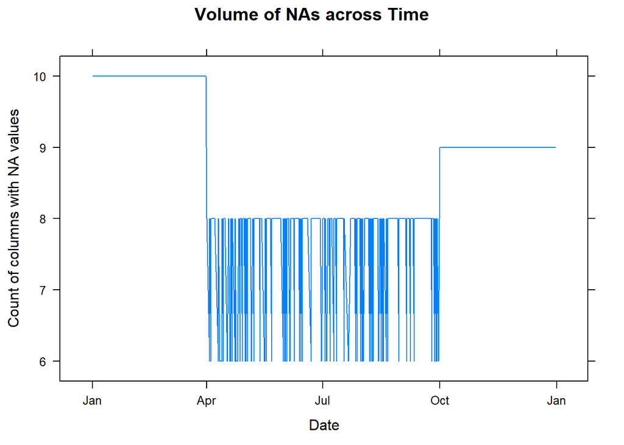

```r
t$naVal <- rowSums(is.na(t))
xyplot(naVal~date, t, type="l", main="Volume of NAs across Time", auto.key = TRUE, xlab="Date", ylab="Count of columns with NA values")
```

The chart shows that more columns are missing between Jan to Apr. Fewer during Apr to Oct (Q2 & Q3). It might be worth using just the Apr to Oct duration for our prediction models.

## Correlation plot

```r
a <- cor(t[6:32], use = "pairwise.complete.obs")
```

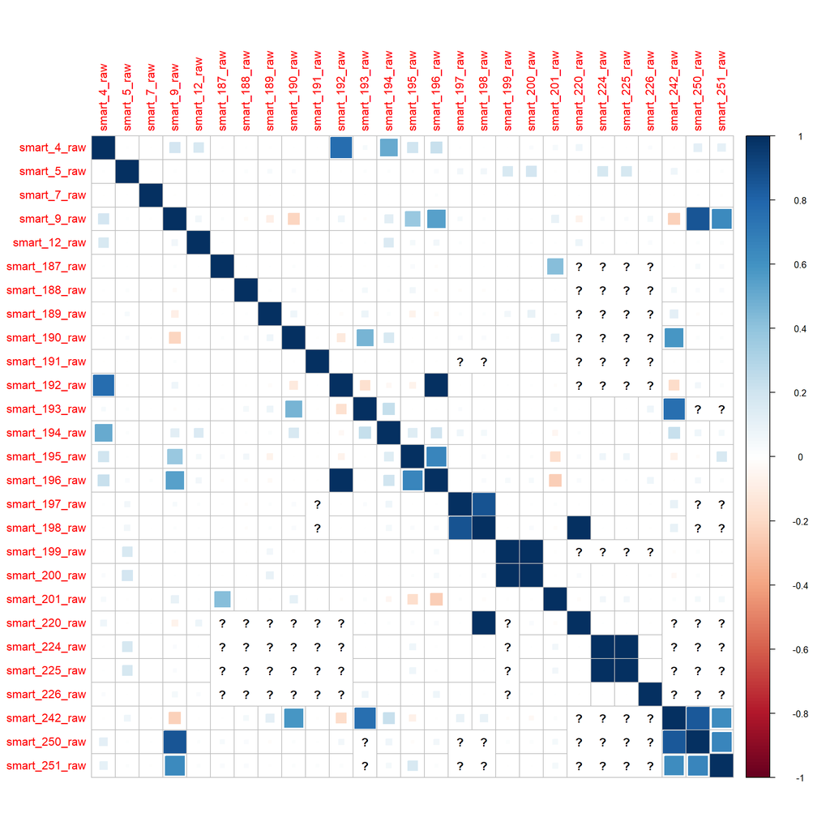

```r
corrplot(a, method="square")
```